# ML_2_Summary

### Model Tests:

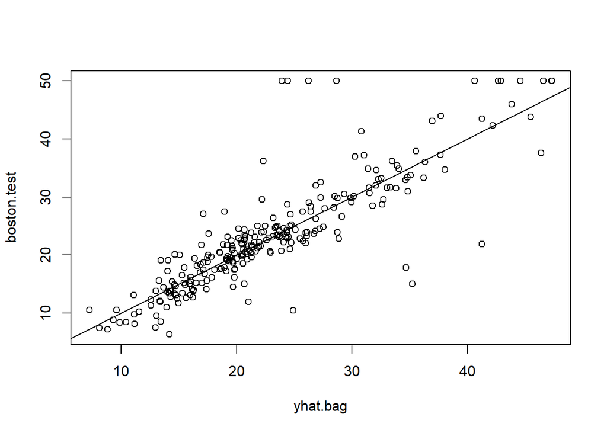

```r
yhat.bag=predict(bag.boston, newdata = Boston[-train,])
plot(yhat.bag, boston.test)
abline(0,1)
```

```r
mean((yhat.bag-boston.test)^2)
```

```
## [1] 23.59273
```

### Model Improvements:

A model can be improved by changing the mtry argument and how many variables you want build a random forest on or by altering the amount of trees the forest is made of using the ntrees argument.

```r
set.seed(1)
rf.boston=randomForest(medv~., data = Boston, subset = train, mtry=6, importance=TRUE, ntrees = 25)
```

The dataset that isn’t used to train the model is then your “Out-Of-Bag” Sample, or your test dataset. Estimate the accuracy of the random forest using the Out-of-Bag sample.

```r
yhat.rf=predict(rf.boston, newdata = Boston[-train,]) ## newdata is your Out-of-Bag data
mean((yhat.rf-boston.test)^2)
```

```
## [1] 19.62021
```

With the ‘importance = TRUE’ argument, you can then see which features are most, or least, important to the random forest. Call this using varImpPlot()

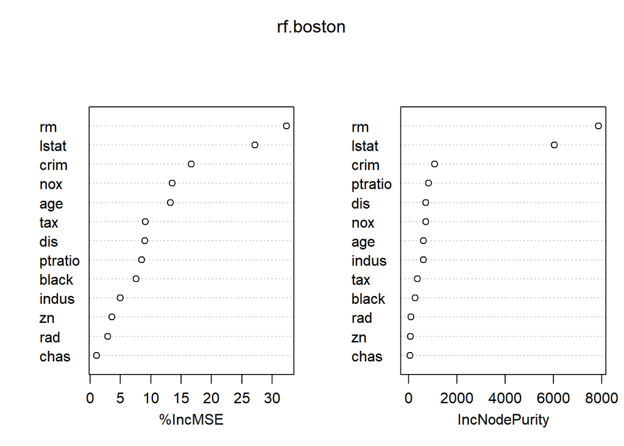

```r
varImpPlot(rf.boston)
```

### Comprehensive Example:

First thing we want to do is load the dataset and remove any observations where salary is missing.

```r
library(MASS)
library(tree)
hitters <- ISLR::Hitters
hitters<-hitters[-which(is.na(hitters$Salary)), ]
hitters$Salary<-log(hitters$Salary)
```

We’ll then create a training set consisting of the first 200 hitters, and a test set consisting of the remaining observations.

```r
train<-1:200
hitters.train <- hitters[train,]
hitters.test <- hitters[-train,]
```

Then we use randomForest including all 19 variables. It will default to 500 trees.

```r
library(randomForest)
set.seed(1)
bag.hitters= randomForest(Salary~.,data=hitters.train,
                            mtry=19,importance =TRUE) #use all 19 variables for bagging
yhat.bag <- predict(bag.hitters , newdata=hitters.test)
mean((yhat.bag - hitters.test$Salary)^2)
```

```
## [1] 0.2301184
```

Call the varImpPlot to see which variables are most important to this random forest

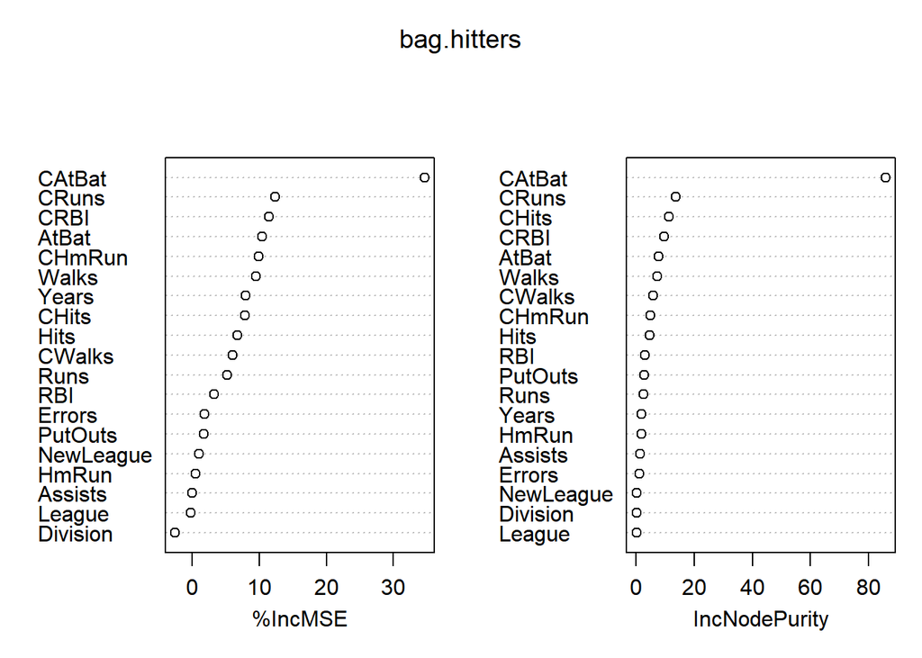

```r
varImpPlot(bag.hitters)
```

## Boosting

Author: Team 15 I think (this was thrown in last minute)

### Applied Exercise No. 10

In this exercise, we’ll use boosting to predict **Salary** in the Hitters data set.

First thing we want to do is load the dataset and remove any observations where salary is missing.

```r
library(MASS)
library(tree)
hitters <- ISLR::Hitters
hitters<-hitters[-which(is.na(hitters$Salary)), ]
hitters$Salary<-log(hitters$Salary)
```

We’ll then create a training set consisting of the first 200 hitters, and a test set consisting of the remaining observations.

```r
train<-1:200
hitters.train <- hitters[train,]
hitters.test <- hitters[-train,]
```

From there, we’ll perform boosting on the training set with 1,000 trees for a range of values of the shrinkage parameter lambda. Produce a plot with different shrinkage values on the x-axis and the corresponding training set MSE on the y-axis.

```r
library(gbm)
```

```r
set.seed(1)
boost.hitters<-gbm(Salary~.,data = hitters.train, distribution = "gaussian",
    n.trees = 1000)
values = 10^seq(-9, 0, by = 0.04) #shrinkage values
mse.train<-vector(mode="numeric")
mse.test<-vector(mode="numeric")
for (i in 1:length(values)) {
 boost.hitters.train<-gbm(Salary~.,data = hitters.train, distribution = "gaussian",
                     n.trees = 1000, shrinkage = values[i])
 pred.boost.train <- predict(boost.hitters.train, newdata = hitters.train, n.trees = 1000)
 pred.boost.test <- predict(boost.hitters.train, newdata = hitters.test, n.trees = 1000)
 mse.train[i]<-mean((pred.boost.train-hitters.train$Salary)^2)
 mse.test[i] <- mean((pred.boost.test-hitters.test$Salary)^2)
}
plot(values,mse.train,ylab = "Train MSE", xlab = "Shrinkage Values", type = 'b', col = "forestgreen")
best_mse<-min(mse.train) #use the one sd rule to pick the best shrinkage value and then use that model for the test
best_mse #0.0005325252
```

```
## [1] 0.0005325252
```

```r
stdev= sd(mse.train[2:226])#this has the intercept in it so we don't want it to skew
stdev #0.3343355
```

```
## [1] 0.3343355
```

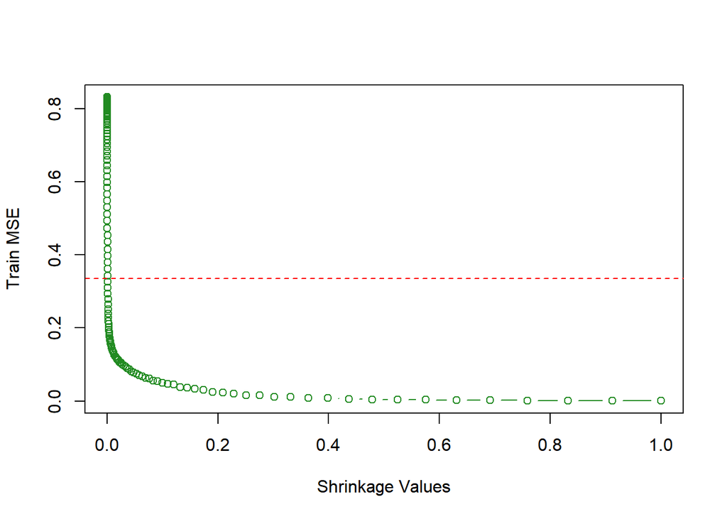

```r
abline(h=(best_mse + stdev), col = "red", lty = "dashed") #It's hard to see what is the best shrinkage value from this plot
```

```r
dataframe<-data.frame(values,mse.train) #make a dataframe and find the
dataframe
```

```
##           values    mse.train
## 1   1.000000e-09 0.8320118926
## 2   1.096478e-09 0.8320117947
## 3   1.202264e-09 0.8320116942
## 4   1.318257e-09 0.8320115761
## 5   1.445440e-09 0.8320114472
## 6   1.584893e-09 0.8320113080
## 7   1.737801e-09 0.8320111490
## 8   1.905461e-09 0.8320109851
## 9   2.089296e-09 0.8320108006
## 10  2.290868e-09 0.8320105942
## 11  2.511886e-09 0.8320103791
## 12  2.754229e-09 0.8320101239
## 13  3.019952e-09 0.8320098679
## 14  3.311311e-09 0.8320095784
```

[output cut: 212 more lines]

Now we’ll produce a plot on the test set.

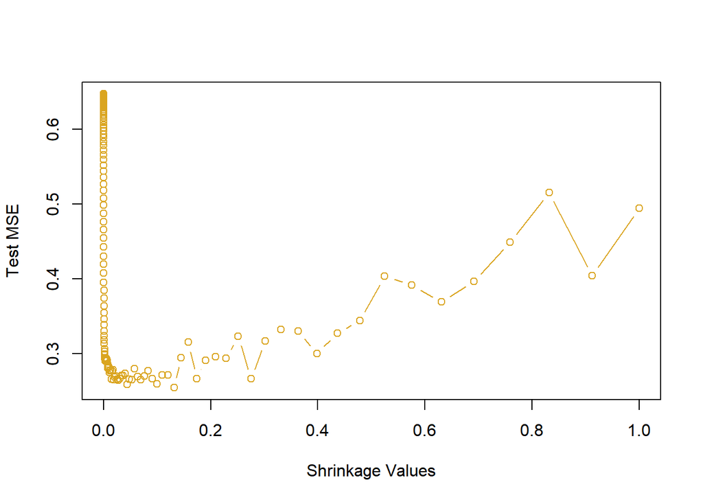

```r
plot(values,mse.test,ylab = "Test MSE", xlab = "Shrinkage Values", type = 'b', col = "goldenrod" )
```

```r
0.0005325252+.334335 #add the best mse to the 1sd to get the maximum mse possible. It is 0.3348675. This is the upper bound.
```

```
## [1] 0.3348675
```

```r
#when we find this in the dataframe, we see the corresponding shrinkage value is 1.202264e-03. so we use this for the best model.
```

## Support Vector Classifier and Support Vector Machine

Author: Carrington Metts

### Summary/description

A **support vector classifier (SVC)** creates a linear hyperplane to separate two classes of data. It is similar to trees, but with only two regions. Additionally, the boundary does not have to be strictly horizontal or vertical. **Support vector machines (SVMs)** are simply SVCs with nonlinear separating hyperplanes. For SVMs, the two most commonly used separators are polynomial and radial.

After creating the separating hyperplane, the SVC/SVM classifies each observation based on which side of the hyperplane it lies on.

### When to employ this method/model

SVCs and SVMs are used for binary classification problems. They work best when the classes are entirely or mostly separable.

### Model Code and Inputs

SVC and SVM models are created using the svm() function from the e1071 library. The syntax is:

```r
library(e1071)
svm(svmfit=svm(y~x, data=data_frame , kernel ="____", cost=_____, degree=_____, gamma=_____, scale=FALSE))
```

The parameters are:

- *y*: the response variable (which should be binary categorical). It **must** be encoded as a factor.
- *x*: the model features. There may be one or muliple. You can use . to specify all features in the given dataframe.
- *data*: the dataframe containing the data.
- *kernel*: the shape of the hyperplane. Use ‘linear’ for a linear SVC, ‘polynomial’ for a polynomial SVM, and ‘radial’ for a radial SVM.
- *cost*: the value of the cost tuning parameter, which dictates the size of the SVC margins. If not specified, this is determined through cross-validation.
- *degree*: the degree of the polynomial SVM hyperplane. This is **only** required for polynomial SVMs. If not specified, this is determined through cross-validation.
- *gamma*: a tuning parameter for radial SVMs. A large gamma means distant observations have little effect on the classification of a given observation. A small gamma means distant observations will have a larger effect. This is **only** required for radial SVMs. If not specified, this is determined through cross-validation.
- *scale*: dictates whether the numeric X variables should be centered and scaled. It’s usually a good idea to set scale=TRUE.

### Model Tests

As previously mentioned, the values of cost, degree, and gamma are usually determined through cross-validation. We use the tune() function from e1071. For a **linear SVM**, the only applicable parameter is cost. The syntax is:

```r
tune_out <- tune(svm, y~x, data=data_frame, kernel='linear',
                 ranges=list(cost=c(0.001, 0.01, 0.1, 1, 5, 10, 100)), scale=TRUE)
```

This function performs 10-fold cross-validation for each of the specified values of cost.

For a **polynomial SVM**, it is also necessary to determine the optimal degree. This time, the cross-validation is performed for every combination of degree and cost. The syntax is:

```r
tune_out_poly <- tune(svm, y~x, data=data_frame, kernel='polynomial',
                ranges=list(cost=c(0.001, 0.01, 0.1, 1, 5, 10, 100),
                            degree=c(2,3,4,5)), scale=TRUE)
```

Finally, for a **radial SVM**, it is necessary to determine the optimal cost and gamma. The syntax is the same as for the previous two cases:

```r
tune_out_radial <- tune(svm, y~x, data=data_frame, kernel='radial',
                ranges=list(cost=c(0.001, 0.01, 0.1, 1, 5, 10, 100),
                            gamma=c(0.5,1,2,3,4)), scale=TRUE)
```

To see the results of the cross-validation, use the summary() function:

```r
summary(tune_out)
```

This will show the cross-validated error rates for each of the parameters (or combinations of parameters).

The best model is the model with the lowest error rate. For SVMs, it is **not** necessary to use the one-standard-deviation rule to minimize model complexity, since a higher-degree model will not be any more complex than a lower-degree one. Therefore, to automatically pick the best model, use $best.model:

```r
best_model <- tune_out$best.model
summary(best_model)
```

This summary function will give more information about the chosen model, including the number of support vectors.

### Model Predictions

Since the best model is determined with cross-validation, there may not be a test and training set. However, the predict() function can still be used to show the prediction for each data point. The syntax is:

```r
predictions <- predict(model, newdata = subset(dataframe, select=-c(y)))
table(predict=predictions, truth=dataframe$y)
```

The model parameters are:

- *model* is the name of the SVM model
- *newdata* is the data for which the prediction is being made
  - In this case, we’re making predictions on the entire dataset.
  - The model is built on the features, so we need to remove the response variable (Y) from the dataset
  - If we had test and training sets that were split into X and Y, we would not need to include the select() portion
- *dataframe* is the dataframe containing the data to make the prediction

### Plots

It is possible to visualize the SVM boundary in a plot. However, the plots may be difficult to interpret if there are more than two features. The general syntax for plotting is:

```r
plot(model, dataframe, x1~x2, slice=list(x3=___, x4=___, ...))
```

The function inputs are:

- *model* is the name of the SVM model (i.e. the best model chosen after cross-validation)
- *dataframe* is the name of the data frame where the data is stored
- *x1* and *x2* are features. If there are only 2 features in the model, it is not necessary to specify them here.
- *slice* is an optional argument that fixes the values for all features except x1 and x2. That is, the plot will show the decision boundary with the assumption that every observation has the same value of x3, x4, etc.
  - If there are only 2 features in the model, there is no need to specify slice
  - If there are more than 2 features, slice is optional. The default value for all features is 0

Each data point is either red or black, depending on its class. Support vectors are represented with crosses.

Because it is difficult to project higher-dimensional space into 2 dimensions (which is what slice is doing), SVM plots may be difficut to interpret if there are more than 2 features.

### Comprehensive Example

The goal of this exercise is to use a support vector classifier and support vector machines (SVMs) to predict whether a car will get high or low gas mileage. To do so, we will use the Auto dataset from the ISLR library. The dataset contains 392 observations of 9 variables.

```r
# Prepare environment
rm(list=ls())
library(ISLR) #Auto data
library(e1071) #SVM functions
data(Auto)

# Code response as a binary factor (required for SVMs)
## determine whether each car's MPG is greater than the median for the data
medianMPG <- median(Auto$mpg) #median MPG
Auto$binaryMPG <- as.factor(Auto$mpg > medianMPG)

# Remove variables
## Numeric MPG is replaced with binaryMPG
## name is a string that will introduce many unwanted coefficients
Auto <- subset(Auto, select=-c(mpg, name))

# Scale data
## This could also be done with scale=True in the model
Auto$cylinders <- scale(Auto$cylinders)
Auto$displacement <- scale(Auto$displacement)
Auto$horsepower <- scale(Auto$horsepower)
Auto$weight <- scale(Auto$weight)
Auto$acceleration <- scale(Auto$acceleration)
Auto$year <- scale(Auto$year)
Auto$origin <- scale(Auto$origin)

# SVC Model
## Perform cross-validation with different values of the cost parameter
set.seed(12)
tune.out <- tune(svm, binaryMPG~., data=Auto, kernel='linear',
                 ranges=list(cost=c(0.001, 0.01, 0.1, 1, 5, 10, 100)), scale=TRUE)
summary(tune.out)
```

```
##
## Parameter tuning of 'svm':
##
## - sampling method: 10-fold cross validation
##
## - best parameters:
##  cost
##  0.01
##
## - best performance: 0.09173077
##
## - Detailed performance results:
##    cost      error dispersion
## 1 1e-03 0.13243590 0.04220959
## 2 1e-02 0.09173077 0.05085151
## 3 1e-01 0.10179487 0.05319595
## 4 1e+00 0.09692308 0.05482158
## 5 5e+00 0.10205128 0.05242390
## 6 1e+01 0.10205128 0.05242390
## 7 1e+02 0.09179487 0.05118295
```

```r
## Get the best cross-validated model
bestmod <- tune.out$best.model
summary(bestmod)
```

```
##
## Call:
## best.tune(method = svm, train.x = binaryMPG ~ ., data = Auto, ranges = list(cost = c(0.001,
##     0.01, 0.1, 1, 5, 10, 100)), kernel = "linear", scale = TRUE)
##
##
## Parameters:
##    SVM-Type:  C-classification
##  SVM-Kernel:  linear
##        cost:  0.01
##
## Number of Support Vectors:  166
##
##  ( 83 83 )
##
##
## Number of Classes:  2
##
## Levels:
##  FALSE TRUE
```

```r
## Best model has cost of 0.01 and 166 support vectors
## It misclassifies 9.17% of the observations

## Show model predictions for each data point
yhat <- predict(bestmod, newdata = subset(Auto, select=-c(binaryMPG))) #model only accepts features, not the Y variable
table(predict=yhat, truth=Auto$binaryMPG) #confusion matrix
```

```
##        truth
## predict FALSE TRUE
##   FALSE   170    9
##   TRUE     26  187
```

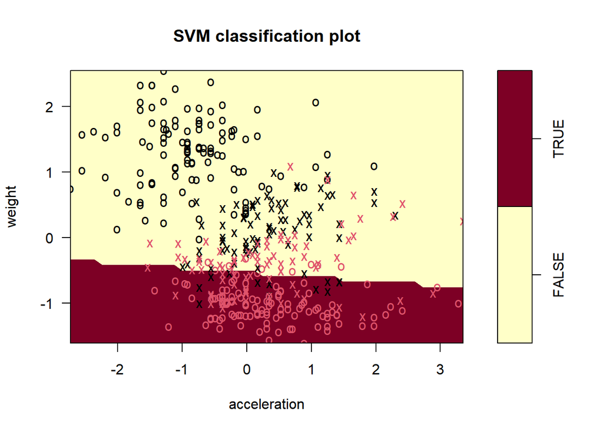

```r
## Plot (more than 2 features: not recommended)
plot(bestmod, Auto, weight~acceleration)
```

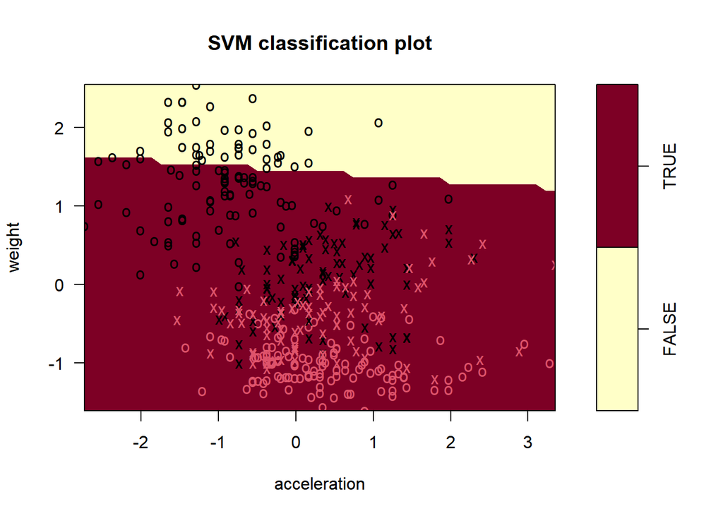

```r
plot(bestmod, Auto, weight~acceleration, slice=list(displacement=-0.5,
                                               horsepower=-0.5,
                                               year=2,
                                               cylinders=0,
                                               origin=0))
```

```r
# Polynomial SVM
## Do cross-validation to find best combination of cost and degree
polysvm <- tune(svm, binaryMPG~., data=Auto, kernel='polynomial',
                ranges=list(cost=c(0.001, 0.01, 0.1, 1, 5, 10, 100),
                            degree=c(2,3,4,5)))
summary(polysvm)
```

```
##
## Parameter tuning of 'svm':
##
## - sampling method: 10-fold cross validation
##
## - best parameters:
##  cost degree
##    10      3
##
## - best performance: 0.07153846
##
## - Detailed performance results:
##     cost degree      error dispersion
## 1  1e-03      2 0.54339744 0.02974011
## 2  1e-02      2 0.42346154 0.06158014
```

[output cut: 26 more lines]

```r
## Pick best polynomial model
bestpoly <- polysvm$best.model
summary(bestpoly)
```

```
##
## Call:
## best.tune(method = svm, train.x = binaryMPG ~ ., data = Auto, ranges = list(cost = c(0.001,
##     0.01, 0.1, 1, 5, 10, 100), degree = c(2, 3, 4, 5)), kernel = "polynomial")
##
##
## Parameters:
##    SVM-Type:  C-classification
##  SVM-Kernel:  polynomial
##        cost:  10
##      degree:  3
##      coef.0:  0
##
## Number of Support Vectors:  99
##
##  ( 49 50 )
##
##
## Number of Classes:  2
##
## Levels:
##  FALSE TRUE
```

```r
# Radial SVM
## Do cross-validation to find best combination of cost and gamma
radsvm <- tune(svm, binaryMPG~., data=Auto, kernel='radial',
                ranges=list(cost=c(0.001, 0.01, 0.1, 1, 5, 10, 100),
                            gamma=c(0.5,1,2,3,4)))
summary(radsvm)
```

```
##
## Parameter tuning of 'svm':
##
## - sampling method: 10-fold cross validation
##
## - best parameters:
##  cost gamma
##     1   0.5
##
## - best performance: 0.06884615
##
## - Detailed performance results:
##     cost gamma      error dispersion
## 1  1e-03   0.5 0.56121795 0.03949843
## 2  1e-02   0.5 0.56121795 0.03949843
```

[output cut: 33 more lines]

```r
## Pick best radial model
bestrad <- radsvm$best.model
summary(bestrad)
```

```
##
## Call:
## best.tune(method = svm, train.x = binaryMPG ~ ., data = Auto, ranges = list(cost = c(0.001,
##     0.01, 0.1, 1, 5, 10, 100), gamma = c(0.5, 1, 2, 3, 4)), kernel = "radial")
##
##
## Parameters:
##    SVM-Type:  C-classification
##  SVM-Kernel:  radial
##        cost:  1
##
## Number of Support Vectors:  125
##
##  ( 64 61 )
##
##
## Number of Classes:  2
##
## Levels:
##  FALSE TRUE
```

## ROC Curves

Author: Alex Russett

### Summary/description

**Receiver Operator Characteristic (ROC)** curves are a graphical plot showing the diagnostic ability of binary classifiers by praphing the output of their respective confusion matrices. This allows faster and easier analysis of SVM models with different gamma values.

The first step is generating data with a non-linear class boundary. “Y” is a factor with 2 levels, ‘1’ and ‘2’.

After creating the separating hyperplane, the SVC/SVM classifies each observation based on which side of the hyperplane it lies on.

### When to employ this method/model

SVCs and SVMs are used for binary classification problems. They work best when the classes are entirely or mostly separable.

### Model Code and Inputs

```r
set.seed(1)
x <- matrix(rnorm(200*2), ncol = 2)
x[1:100, ] <- x[1:100, ] + 2
x[101:150, ] <- x[101:150, ] - 2
y <- c(rep(1, 150), rep(2, 50))
dat <- data.frame(x = x, y = as.factor(y))
summary(dat)
```

```
##       x.1               x.2          y
##  Min.   :-3.9144   Min.   :-4.2649   1:150
##  1st Qu.:-1.0789   1st Qu.:-0.9259   2: 50
##  Median : 0.9699   Median : 0.7546
##  Mean   : 0.5355   Mean   : 0.5406
##  3rd Qu.: 2.1849   3rd Qu.: 1.9965
##  Max.   : 4.4016   Max.   : 4.6492
```

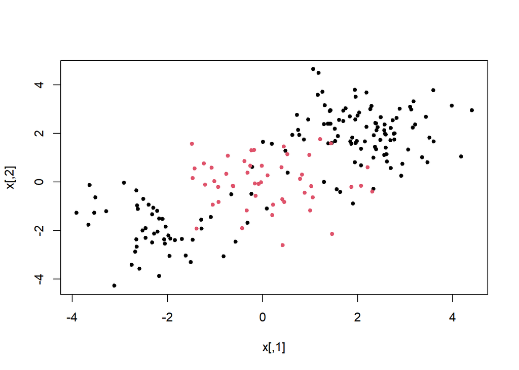

```r
plot(x, col = y, pch = 20)
```

Initial set up of the data:

Plotting the data shows that the class boundary is non-linear.

Next, the data is split into a training and a testing set:

```r
train.index <- sample(1:nrow(dat),nrow(dat)*.5)
train <- dat[train.index,]
test <- dat[-train.index,]
```

### ROC (Receiver Operating Characteristic) Curve Generation

Load the “ROCR” and “e1071” libraries.

```r
library(ROCR)
library(e1071)
```

#### Function Inputs / Paramaters

Next, a function is created to generate an ROC plot. The function inputs are “pred” and “truth”.

**“Pred”** is a vector containing the numerical score for each observation.

**“Truth”** is a vector containing the class label for each observation.

**“Predobject”** creates the prediction object for evaluation using ROCR. Label.ordering specifies the direction, which determines how the negativity or positivity of an observation is determined. “2” is the negative class label and “1” is the positive class label.

**“Perf”** evaluates performance using **TPR (true positive rate)** and **FPR (false positive rate)**.

```r
rocplot =function(pred , truth , ...){
  predob = prediction(pred , truth, label.ordering = c(2,1))
  perf = performance(predob , "tpr", "fpr")
  plot(perf ,...)}
```

Next, we will obtain fitted values, which are numerical scores used to obtain class labels.

In this exercise, we will be comparing models with a gamma set at 2 and another set at 50. The model with gamma set at 2 will be called “svmfit.opt” and the one with 50 will be called “svmfit.flex”.

```r
svmfit.opt <- svm(y~., data = train, kernel = 'radial', gamma = 2, cost = 1, decision.values = TRUE)
fitted.g2.train <- attributes(predict(svmfit.opt, train, decision.values=TRUE))$decision.values

svmfit.flex=svm(y~., data=train,kernel ="radial",gamma=50,cost=1,decision.values =TRUE)
fitted.g50.train=attributes(predict(svmfit.flex,train,decision.values=TRUE))$decision.values
head(fitted.g50.train)
```

```
##            1/2
## 148  1.0004240
## 192 -0.5934886
## 87   0.9998178
## 20   1.0132808
## 112  1.0000652
## 177 -0.9998983
```

The sign of the fitted value determines on which side of the decision boundary the observation lies. If the fitted value exceeds zero then the observation is assigned to one class, and if it is less than zero then it is assigned to the other.

Next, we produce the ROC plot.

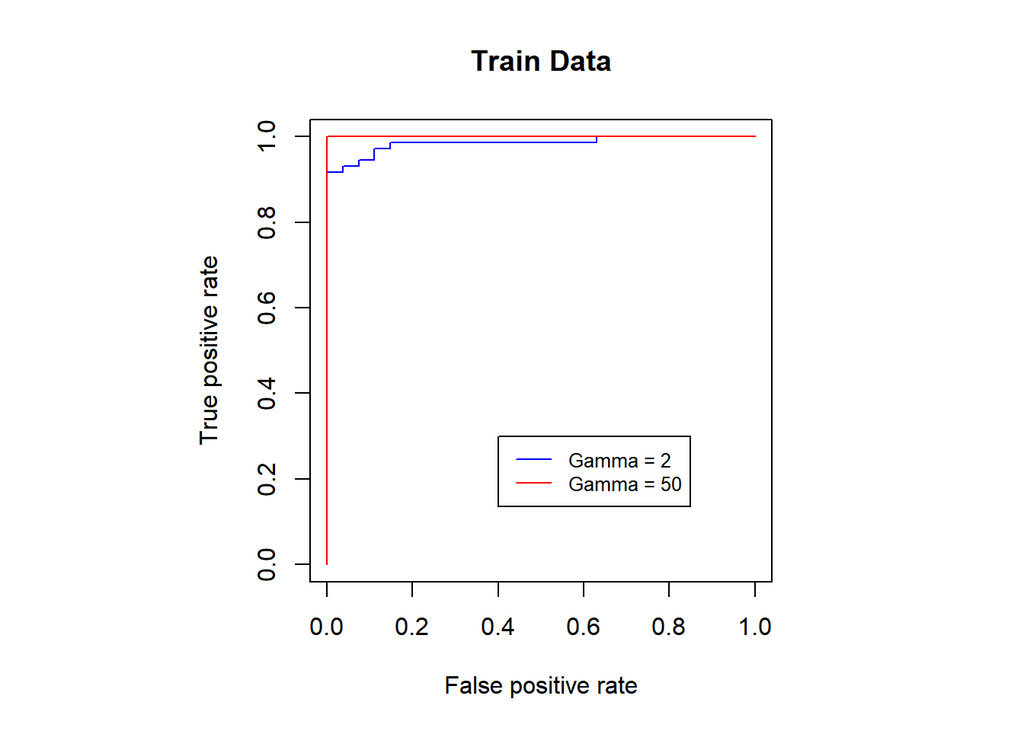

```r
par(mfrow = c(1, 1))
par(pty = "s")       # plot as a square

rocplot(fitted.g2.train,train$y,main="Train Data", col = "blue")
rocplot(fitted.g50.train,train$y, add=TRUE, col="red")         # add = TRUE means add to existing graph

legend(.4, .3, legend=c("Gamma = 2", "Gamma = 50"),col=c("blue", "red"), lty=1:1, cex=0.8)
```

The training model with a gamma of 50 produced more accurate results. We know this because the red line hugs the upper left corner of the graph, meaning that the true positives are maximized.

#### Test Data

Next, we will fit the values for the test set and plot the ROC curves.

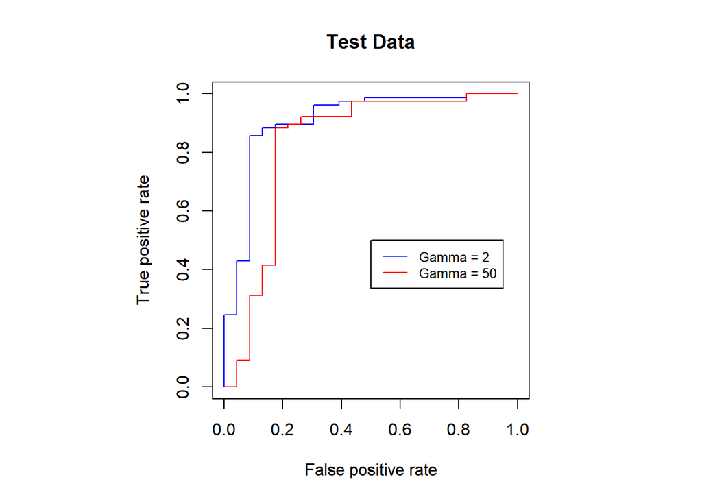

```r
fitted.g2.test=attributes(predict(svmfit.opt,test,decision.values=TRUE))$decision.values
fitted.g50.test=attributes(predict(svmfit.flex,test,decision.values=TRUE))$decision.values

par(pty = "s")
rocplot(fitted.g2.test,test$y,main="Test Data", col = "blue")
rocplot(fitted.g50.test,test$y,add=T,col="red")

legend(.5, .5, legend=c("Gamma = 2", "Gamma = 50"),col=c("blue", "red"), lty=1:1, cex=0.8)
```

The model where gamma = 2 produced the best results.

#### Another ROC plotting method

Another way to plot the ROC curves is using the “pROC” library. The inputs are the same as the “rocplot” function inputs. However, one difference is adding “direction”. With direction = “>”, each observation will be considered positive if it is less than 0 and negative otherwise. If you change the direction, you reverse the positive and negative predictions and therefore reverse the ROC curve.

The plots have Area Under the Curve (AUC) labels, which help evaluate the model performance. The best models will have the highest AUC score.

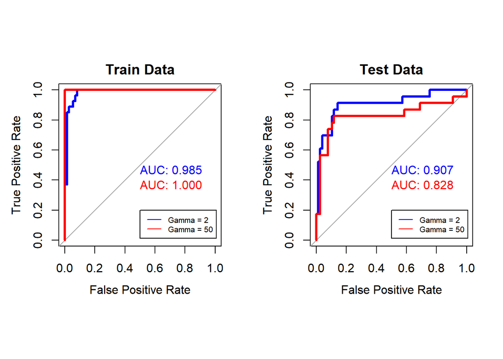

```r
library(pROC)

par(mfrow = c(1, 2))
par(pty = "s")

### Train Data
plot(roc(train$y,fitted.g2.train,direction = ">"), col = "blue",
     legacy.axes= TRUE, lwd = 3, main = "Train Data", print.auc=TRUE,       #print.auc=TRUE: prints AUC label
     xlab = "False Positive Rate", ylab= "True Positive Rate")

plot(roc(train$y,fitted.g50.train,direction = ">"), col = "red", add = TRUE,
     lwd = 3, print.auc = TRUE, print.auc.x = 0.5, print.auc.y = 0.4)     #print.auc.x/y: coordinates for label

legend(.5, .2, legend=c("Gamma = 2", "Gamma = 50"),col=c("blue", "red"), lty=1:1, cex=0.65)

### Test Data
plot(roc(test$y,fitted.g2.test,direction = ">"), col = "blue",
     legacy.axes= TRUE, lwd = 3, main = "Test Data", print.auc=TRUE,
     xlab = "False Positive Rate", ylab= "True Positive Rate")

plot(roc(test$y,fitted.g50.test,direction = ">"), col = "red", add = TRUE,
     lwd = 3, print.auc = TRUE, print.auc.x = 0.5, print.auc.y = 0.4)

legend(.5, .2, legend=c("Gamma = 2", "Gamma = 50"),col=c("blue", "red"), lty=1:1, cex=0.65)
```

As we saw earlier, a gamma of 50 works best for the train data and a gamma of 2 works best for the test data.

## Principal Component Analysis

Author: Genevieve Riley

### Summary/description

**Principal Component Analysis (PCA)** is an *unsupervised* type of learning.

- PCA is a **dimension reduction technique.** PCA uses feature extraction to reduce dimensions.
  - That means, PCA is a method to reduce a high number of features, p, down to only the ones contributing most significantly to explaining some response variable, Y.
- Narrowing down features (ie X variables) is called dimension reduction.
  - Reducing dimensions is important to avoid **overfitting.**
  - Unlike *feature elimination*, which entirely drops input variables of low importance, such as lasso or forward/backwards selection, *feature extraction* will make **new variables which are combinations of X_features.**
  - These “new variables” are (you guessed it!) the principal components!!!
  - Principal components are *linear combinations of x features.*
  - PCA is similar to ridge regression’s technique of choosing variables, because we do not get rid of variables; we simply *reduce weight of variables depending on importance.*
  - Other dimension reduction techniques we’ve seen in chapter 6: ridge, lasso, forward/backwards selection…
- Since this is unsupervised, we have no Y variable. So, how do we know if a variable is important?!
  - We make an assumption that **variables with higher variance have a greater ability to explain data.**
- How do we know if a principal component has higher or lower variance?!
  - Using a little linear algebra magic…

### When to employ this method/model

PCA is useful for…

1. Data Visualization
- Visualize relationship between variables
- Do variables have positive or negative relationship? No relationship?
2. Dimension reduction before supervised learning
- When you have *tons* of features and want to identify just the important/relevant features before running a supervised model.
3. You don’t care about interpretability of the variables
- Since PCs are combinations of the Features, it’s not clear cut how to interpret them
- If you just want a higher performing model that runs faster from having fewer features, this is a great option

### Model Code and Inputs

PCA is done using the **prcomp()** function from the **stats** library.

- Arguments:
  - x = a numeric or complex matrix (or data frame) which provides the data for the principal components analysis.
  - retx = Return X; a logical value indicating whether the rotated variables should be returned. Default = TRUE
  - center = a logical value indicating whether the variables should be shifted to be zero centered. Default = TRUE
  - scale = a logical value indicating whether the variables should be scaled to have unit variance before the analysis takes place. Default = FALSE
  - tol =  
    a value indicating the magnitude below which components should be omitted. Default = NULL
  - rank = optionally, a number specifying the maximal rank, i.e. maximal number of principal components to be used. Default = NULL

The syntax is:

```r
library(stats)
#   pr.model <- prcomp(x, retx = TRUE, center = TRUE, scale. = FALSE,
          #tol = NULL, rank. = NULL))
```

The main parameters we care about are:

- x
- center
- scale

### Model Tests

PCA has *no tuning or testing per se,* ; instead, we need to pick **the best number of Principal Components to include.**

- How do we choose the number of principal components?
- **ANSWER by plotting the PVE!**

What is PVE?

- PVE = **Percent of Variance Explained**
- each principal component has a PVE
- principal components are listed in order of pve
- therefore, the **first principal component has the highest pve**

How to find PVE?

1. Call prcomp() on data
2. Use $sdev on model
   - returns the standard devation of the *principal components*
3. Square the sdevs of the principal components
   - This returns variance, because sd^2 = variance
4. Find total variance
5. Divide principal component variance/total variance

How do we choose the number of Principal Components?

- See where the additional variance explained is insignificant OR
- When percent explained meets a threshold
  - Ex: choose the minimum number of principal components that explains at least 90% of variance

### Plots

Plot the PVE to see **how many principal components to include**

- PLOT 1: regular plot of PVE of each of 4 principal components
- PLOT 2: cumulative sum of PVE
- Interpretation: How do we use this is choose PVE?
  - Choose PVEs that explain **most of the variance**
  - Ans: We would likely choose first 3 PCs

```r
plot(pve, xlab = "Principal Component",
     ylab = "Proportion of Variance Explained",
     ylim = c(0,1), type = 'b')
plot(cumsum(pve), xlab = "Principal Component",
     ylab = "Cumulative Proportion of Variance Explained",
     ylim = c(0,1), type = 'b')
```

[output not shown]

First 3 principal components contain roughly 95% of the variance. Even 2 principal components explains about 87% of variance which is substantial!

- Choose PVEs based on a percent of variance threshold OR judgment
- If threshold is explaining 90% variance, would choose 3 PCs

Additional plot: ** Biplot of first 2 principal components**

- Use 2 principal components since it’s easier to visualize 2D than 3D+

```r
biplot(pr.out, scale = 0)
```

[output not shown]

### Comprehensive Example

Problem: **Use PCA to determine which principal components are important.**

1. Choose the minimum number of PCs that ensures 90% of variance is explained
2. Display the first 5 principal component scores
3. Display the eigenvectors that transform the scaled data
4. Plot the cumulative PVE

```r
library(stats)

data <- USArrests          # load data
scaled.data <- scale(data) # center and scale
class(scaled.data)         # ensure data is matrix


# 1. Call prcomp()
pr.out <- prcomp(scaled.data, scale. = TRUE)   # can't hurt to set scale=TRUE, even if already scaled

# 2. Use $sdev
pr.sd <- pr.out$sdev

# 3. Square sdevs
pr.var <- pr.sd^2

# 4. Find total variance
pr.sum.var <- sum(pr.var)

# 5. Divide pc var/total var
(pve <- pr.var/pr.sum.var)



## display first 5 scores
pr.out$x[1:5]

## display eigenvectors that transform the scaled data
pr.out$rotation

## plot cumulative PVE
plot(cumsum(pve), type = 'b')
abline(h = 0.9)
```

[output not shown]

**The results are in!** Notice that PVEs are in descending order…

- [1] 0.62006039 0.24744129 0.08914080 0.04335752
- How do we interpret the results?
- The 1st PC contains 62% of variance, 2nd has 24.7%, 3rd has 8% and 4th has 4%
- all PVE add to 100%…intuitively…can’t have a pie that adds to > 100% unless you’re the media

**Question answers:**

### So…Eigenvectors!

Eigenvectors are the values found using $rotation

- They are labeled **rotation** because they are the values that reorient the (scaled) data points!
- The scaled data * rotation = scores
- scores are found using the $x operator
- By now, perhaps you see that **scores (i.e. $x) = $rotation * scaled data**

**Proof in R that $rotation * scaled data = $x**

```r
# 1.
calculated.scores = scaled.data%*%pr.out$rotation # matrix multiplication
calculated.scores[1:5]

## ANS [1] -0.9756604 -1.9305379 -1.7454429  0.1399989 -2.4986128
# 2.
model.scores = pr.out$x[1:5]
model.scores[1:5]

## ANS [1] -0.9756604 -1.9305379 -1.7454429  0.1399989 -2.4986128
# ta da
```

### PCA Q & yAy

1. PCA is: supervised/unsupervised
2. Every record or observation has an: eigenvalue/score
3. The amount of variance explained by a principal component is called the eigenvalue/eigenvector
4. Another name for the coefficients in a principal component is: scores/loadings
5. Another name for the eigenvectors is: scores/loadings
6. We find the loadings using pca.model$: x/rotation
7. how many principal components are in a data set with 4 features and 50 observations?: 4/50
- recall: number of PC’s = minimum of n-1 and p
8. We scale the variables using scale = TRUE so that: mean is 1, sd is 0/ mean = 0, sd = 1
9. Principal components are linear combinations of: X variances/ X features

### Q & yAy Answers

1. unsupervised
2. score
3. eigenvalue
4. loadings
5. loadings
6. $rotation
7. 4
- min(50-1, 4) = 4
8. mean = 0, sd = 1
9. X features

## K-Means Clustering

Author: Mr. Justin Pender

### Summary/description

*K-Means Clustering* is a form of *unsupervised learning*. It involves partitioning data into K distinct, non-overlapping parts.

- The value for K must be set manually, and the algorithm will sign each observation to exactly one of the K clusters.
- The goal of K-means clustering is to reduce *within-cluster variation* as much as possible.
  - *Within-cluster variation* is calculated by squaring the Euclidean distance. It is the sum of all the pairwise squared Euclidian distances between all observations in the *k*th cluster.
  - The K-Means clustering algorithm finds the optimal partitioning of observations into *K* clusters such that the sum of within-cluster variatons is minimized.
- The K-Means clustering algorithm follows these steps:
  1. Randomly assign a number, from 1 to *K*, to each of the observations.
  2. Iterate until the cluster assignments stop changing.
     1. Compute the *centroid* for each cluster: the vector of feature means for observations in that cluster.
     2. Assign each observation to the cluster with the closest centroid.
- The K-Means algorithm cannot guarantee a global optimum. As such, it is important to run the algorithm multiple times from different random initial configurations.

### When to employ this method/model

K-means clustering is especially useful when no clear predictor variable is known. It is a powerful form of unsupervised learning, allowing data to be grouped. It can be used on its own, but it is especially useful as a preprocessing step for supervised learning (for example, using the cluster ID as a feature). It can also be used for pattern recognition, customer segmentation, and as a way to reduce data size (by focusing on a single cluster at a time).

### Model Code and Inputs

The **kmeans()** function in base R is used to perform clustering.

- A sample function looks like this:
  - kmeans(dataset, centers, nstart=10)
  - dataset: a numeric matrix of data
  - centers: the number of clusters, *K*
  - nstart: The number of random sets to be chosen to start the k-means algorithm
    - This is the number of initial allocations of observations to clusters to run
    - nstart is usually set to either 20 or 50
- Outputs
  - $cluster: gives cluster assignment of each observation
  - $tot.withinss: gives the within-cluster sum of squares
  - $withinss: gives the within-cluster sum of squares of each cluster
  - $betweenss: gives residuals between clusters
  - $centers: gives the cluster centers (a mean for each feature for each cluster)

### Model Tests

We want to tune the model to the optimal number of clusters. This can be done with a for loop. Use a scree plot to display results. The goal of K-means is still to minimize the sum of within-cluster variance.

```r
# Create a vector to store 15 totwithiness scores
kmax <- 15
totwithiness<-rep(0,kmax)

# Tune k = 1 to 15
for (k in 1:kmax)
{
  totwithiness[k] = kmeans(MyDF,
                           k, # number of clusters
                           nstart=25,
                           iter.max = 15 # maximum number of iterations allowed
  )$tot.withinss
}

# Scree plot: tot.withinss by k
plot(1:kmax, totwithiness,
     type="b", pch = 19,
     xlab="Number of clusters K",
     ylab="Total within-clusters sum of squares",
     xlim=c(0,kmax+1),)
```

### Plots

```r
plot(MyDF, col=(km.out$cluster+1)
text(MyDF, labels=km.out$cluster,cex=0.9, font=10,pos=4)
```

- Use cluster number as color code
- adding labels to each cluster

We can also use the **fviz_cluster()** function from the **factoextra** package:

```r
fviz_cluster(km.out, data = df)
```

The scree plot listed in the *Model Tests* section is the other plot that is used for K-means. It is used to visualize within-cluster variation across differing values of K.

### Comprehensive Example

```r
set.seed(2)

# Data setup
x=matrix(rnorm(50*2), ncol=2) # two columns of X features, 50 records each
plot(x[,1], x[,2])

# Create more dramatic clusters
F1=rep(0,50) # Create a new feature F1
F1[1:25]=x[1:25,1]+3 # Create the first 50% of F1 values by adding 3 to the first 50% of X1
F1[26:50]=x[26:50,1] # The second 50% of F1 is the same as X1
MyDF = data.frame(F1,x) # Add F1 and x matrix together as the dataframe MyDF
plot(MyDF$X1, MyDF$F1) # See how F1 is related to X1

F2=rep(0,50) # Create a new feature F2
F2[1:25]=x[1:25,2]-4 # Create the first 50% of F2 values by subtracting 4 from the first 50% of X2
F2[26:50]=x[26:50,2] # The second 50% of F2 is the same as X2
MyDF = data.frame(F2,MyDF) # Add F2 to the MyDF dataframe
plot(MyDF$F2, MyDF$X2) # See how F2 is related to X2

# Now we can use F1 & F2 in MyDF as our dataset
MyDF=subset(MyDF, select=-c(X1,X2)) # Remove X1 & X2
attach(MyDF)
plot(F1, F2)

# K-Means Clustering
km.out2=kmeans(MyDF,
               centers = 2, # K = 2 (number of cluster centers)
               nstart=20) # run kmean() with multiple initial cluster assignments (recommended)
# 20 sets of random rows are selected as initial centers

# See cluster assignment of each record
km.out2$cluster # Output differs slightly from book, because MyDF is a dataframe, but x is a matrix

# See total within-cluster sum of squares
km.out2$tot.withinss

# See within-cluster sum of squares of each cluster
km.out2$withinss

km.out2$betweenss
km.out2$centers

# They should add up to be the same as tot.withinss
(sum(km.out2$withinss))

plot(MyDF,
     col=(km.out$cluster+1), # Use cluster number as color code
     main="K-Means Clustering Results with K=2", xlab="", ylab="", pch=20, cex=2)

set.seed(4)

km.out3 = kmeans(MyDF,
                 3,# centers (K) = 3
                 nstart=20)

km.out3
km.out3$tot.withinss

km.out3_1 = kmeans(MyDF,
                   3,
                   nstart=1) # smaller nstart can produce less optimal outcome
km.out3_1$tot.withinss


plot(MyDF,
     col=(km.out$cluster+1),
     main="K-Means Clustering Results with K=3", xlab="", ylab="", pch=20, cex=2)

#######################################################
# Tune the optimal number of clusters (k)

# Create a vector to store 15 totwithiness scores
kmax <- 15
totwithiness<-rep(0,kmax)

# Tune k = 1 to 15
for (k in 1:kmax)
{
  totwithiness[k] = kmeans(MyDF,
                           k, # number of clusters
                           nstart=25,
                           iter.max = 15 # maximum number of iterations allowed
  )$tot.withinss
}

# Scree plot: tot.withinss by k
plot(1:kmax, totwithiness,
     type="b", pch = 19, frame = FALSE,
     xlab="Number of clusters K",
     ylab="Total within-clusters sum of squares")
```

## Hierarchical Clustering

Team 9: Thomas Trankle, Jaida Clarke, Jill van den Dungen, Andrew Tremblay

### Summary/description

*H-Clustering*, another *unsupervised learning* technique, has a few advantages over K-Means Clustering: For one, the number of clusters does not need to be pre-specified. Rather, it is a bottom up construction, where each observation starts in its own cluster. From there, clusters are continuously made and/or combined by a specified linkage method until every observation belongs to the same cluster. This process is defined and visualized in a *dendrogram*, a tree-based representation of the observations, cluster groubings and the respective dissimilarity. Again, hierarchical clustering is called *bottom-up* or *agglomerative* clustering, because the dendrogram (which looks like an upside-down tree) is constructed from the many leaves at the bottom *fusing* one-by-one until they form a single “trunk” at the top. This allows us to not have define the amount of clusters before the algorithm. Instead, we can visually inspect the dendogram to determine where the most appropriate amount of clusters. This is where we choose to cut the tree.

Interpreting the dendrogram is quite intuitive; the height of each fusion point corresponds to how similar the two observations are, which means that those observations at the bottom of the tree which fuse right away are more similar than those closer to the trunk at the top. While greater height between the fusion points of observations denotes greater dissimilarity, there is *no significance* to their horizontal distance.

Clusters are formed by making cuts horizontally across the tree. The further down (towards the leaves) a tree is cut, the more clusters that will result. Therefore, the height of the cut to the dendrogram is analogous to the role of K in K-Means Clustering.

*Hierarchical* refers to the fact that clusters obtained from a cut at a given height are necessarily contained within the resulting clusters of cuts made at greater heights. In other words, they are *nested*.

The algorithm for the *H-Clustering* model is very simple: * A *dissimilarity measure* (usually Euclidean distance) between each pair of observations is established. + *Linkage* defines the dissimilarity between groups of observations. The four most common types of linkage are: + Complete- The largest dissimilarity between a pair of observations when one observation comes from each cluster + Single- The smallest dissimilarity + Average- Mean intercluster dissimilarity + Centroid- Dissimilarity measure between the geographic centers of the pair of clusters

- Each observation begins as its own cluster, and each cluster is then fused to the most similar cluster iteratively until all observations belong to a single cluster.

In place of Euclidean distance-based dissimilarity measures, correlation-based distance can be used. This is useful when features have varying magnitudes or when the shape of the data is highly correlated, since unsupervised learning is very sensitive to scaling.

Linkage Characteristics: * Complete + Maximal intercluster dissimilarity. Compute all pairwise dissimilarities between the observations in cluster A and the observations in cluster B, and record the largest of these dissimilarities * Single + Minimal intercluster dissimilarity. Compute all pairwise dissimilarities between the observations in cluster A and the observations in cluster B, and record the smallest of these dissimilarities. Single linkage can result in extended, trailing clusters in which single observations are fused one-at-a-time * Average + Mean intercluster dissimilarity. Compute all pairwise dissimilarities between the observations in cluster A and the observations in cluster B, and record the average of these dissimilarities * Centroid + Dissimilarity between the centroid for cluster A (a mean vector of length p) and the centroid for cluster B. Centroid linkage can result in undesirable inversions. Whereby inversion two clusters are fused at a height below either of the individual clusters in the dendrogram. This can lead to difficulties in visualization as well as in interpretation of the dendrogram.

Average and complete linkage are generally preferred over single linkage, as they tend to yield more balanced dendrograms.

### When to employ this method/model

Hierarchical Clustering is very similar to K-Means Clustering, except the number of clusters is not needed as an input. Additionally, the dendrogram is useful for visualizing the overall similarity of the data, and for estimating the appropriate number of clusters. Both K-Means and H-Clustering will assign each observation to a cluster, which makes them sensitive to outliers. It’s best to experiment with different unsupervised models and parameters to observe patterns that consistently emerge. Most times, clustering is a good starting point for analysis.

### Model Code and Inputs

We begin with a simple simulated example in which there are **truly two clusters** in the data; the first 25 observations have a mean shift relative to the next 25 observations. This makes sure we have to distinct clusters in our data.

```r
x <- matrix(rnorm (50*2), ncol=2) # Create a 50 X 2 matrix with samples from a
                               # normal distribution

x[1:25,1] <- x[1:25,1]+3   # Move half the points 3 units right and
x[1:25,2] <- x[1:25,2]-4   # 4 units down
```

The **hclust()** function implements hierarchical clustering in R. In the following example, we use the data from above to plot the hierarchical clustering dendrogram using complete, single, and average linkage clustering, with Euclidean distance as the dissimilarity measure.

We begin by clustering observations using complete linkage. The **dist()** function is used to compute the 50 × 50 inter-observation Euclidean distance matrix.

```r
hc.complete <- hclust(dist(x), method="complete") # tells type of cluster method, type of distance used, and total data points
```

We could just as easily perform hierarchical clustering with average or single linkage instead:

```r
hc.average <- hclust(dist(x), method ="average")
hc.single <- hclust(dist(x), method ="single")
hc.centroid <- hclust(dist(x), method ="centroid")
```

We can now plot the dendrograms obtained using the usual **plot()** function.The numbers at the bottom of the plot identify each observation.

Babu, M. M., & Grant, R. (n.d.). Computational Genomics. Horizon Press. (cite for image)

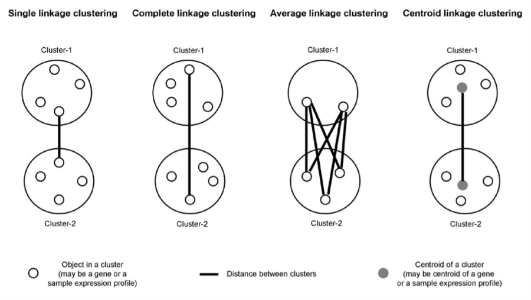

https://www.mrc-lmb.cam.ac.uk/genomes/madanm/microarray/chapter-final.pdf

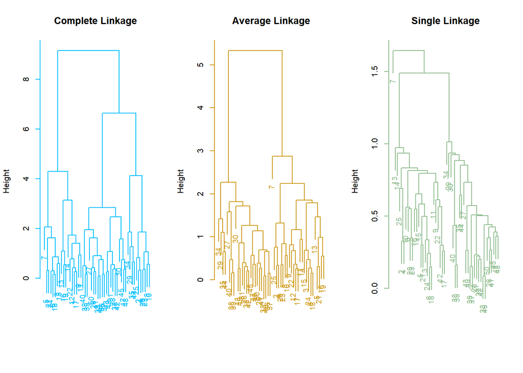

```r
par(mfrow=c(1,3))
plot(hc.complete ,main="Complete Linkage ", xlab="", sub="",
cex=.9, col = "deepskyblue") # produces a cleaner plot that is easy to follow

plot(hc.average , main="Average Linkage", xlab="", sub="",
cex=.9, col = "goldenrod3")

plot(hc.single , main="Single Linkage", xlab="", sub="",
cex=.9, col = "darkseagreen") # produces branches for every single observation. Not the most comprehensive heirachrical plotting method
```

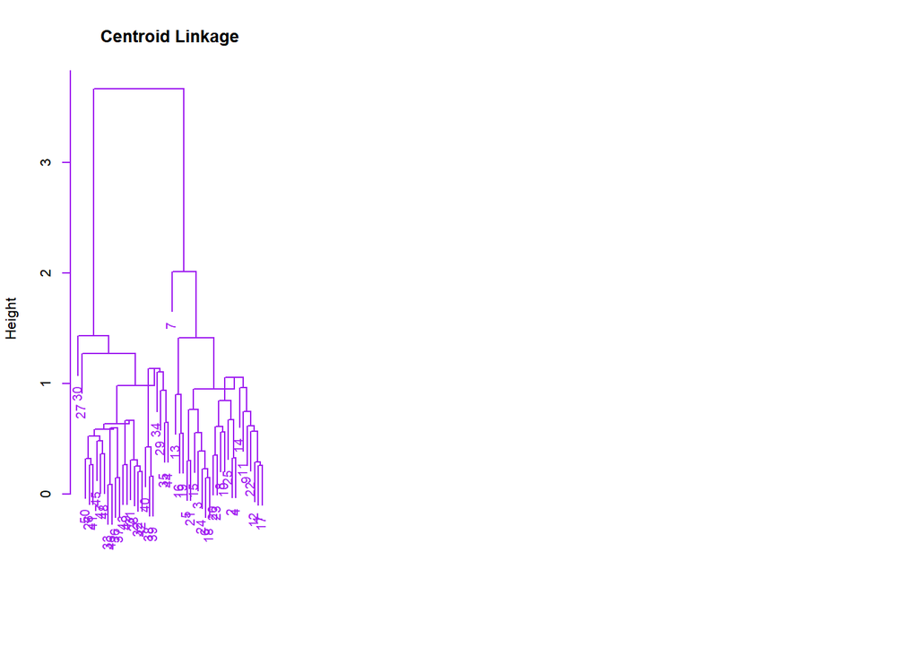

```r
plot(hc.centroid , main="Centroid Linkage", xlab="", sub="",
cex=.9, col = "purple")
```